# Equipo 5: Students Performance

Somos el equipo 5 de FID, compuesto por Arturo Pérez Sánchez, Jacinto José Ruiz Díaz y Yassin Lalj El Assri, y nos hemos puesto como objetivo obtener la máxima nota posible en la asignatura.

Teniendo esto en cuenta, hemos decidido que la temática del proyecto será el estudio del rendimiento académico de los estudiantes de secundaria.

Para el desarrollo del proyecto hemos seleccionado un dataset de la plataforma Kaggle donde analizaremos el rendimiento académico de los estudiantes de secundaria en 3 áreas diferentes (*math*, *reading* y *writing*). El dataset en cuestión consta de 1000 entradas de diferentes alumnos con las siguientes variables:

- **gender (genero)**: male / female
- **race/ethnicity (raza/etnia)**: group A / group B / group C…
- **parental level of education (nivel de educación de los padres)**: some college / associate’s degree…
- **lunch (descuento del comedor)**: standard, free / reduced
- **test preparation course prepareación del test)**: none / completed

```r
library(ggplot2)
library(dplyr)

ds<-read.csv("../StudentsPerformance.csv" , head = TRUE, sep=",")
ds
```

| gender | race.ethnicity | parental.level.of.education | lunch | test.preparation.course | math.score | reading.score | writing.score |
| --- | --- | --- | --- | --- | --- | --- | --- |
| female | group B | bachelor's degree | standard | none | 72 | 72 | 74 |
| female | group C | some college | standard | completed | 69 | 90 | 88 |
| female | group B | master's degree | standard | none | 90 | 95 | 93 |
| male | group A | associate's degree | free/reduced | none | 47 | 57 | 44 |
| male | group C | some college | standard | none | 76 | 78 | 75 |
| female | group B | associate's degree | standard | none | 71 | 83 | 78 |
| female | group B | some college | standard | completed | 88 | 95 | 92 |
| male | group B | some college | free/reduced | none | 40 | 43 | 39 |
| male | group D | high school | free/reduced | completed | 64 | 64 | 67 |
| female | group B | high school | free/reduced | none | 38 | 60 | 50 |

[output cut: 990 more lines]

#### **GÉNERO**

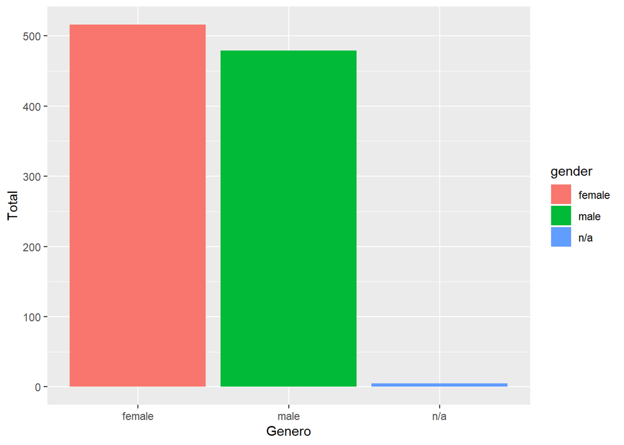

```r
gender_plot <- ggplot(data = ds,
                      aes(x = gender, fill = gender)) +
               geom_bar(stat = "count") +
               xlab("Genero") +
               ylab("Total")
gender_plot
```

#### **ESTUDIOS DE LOS PADRES**

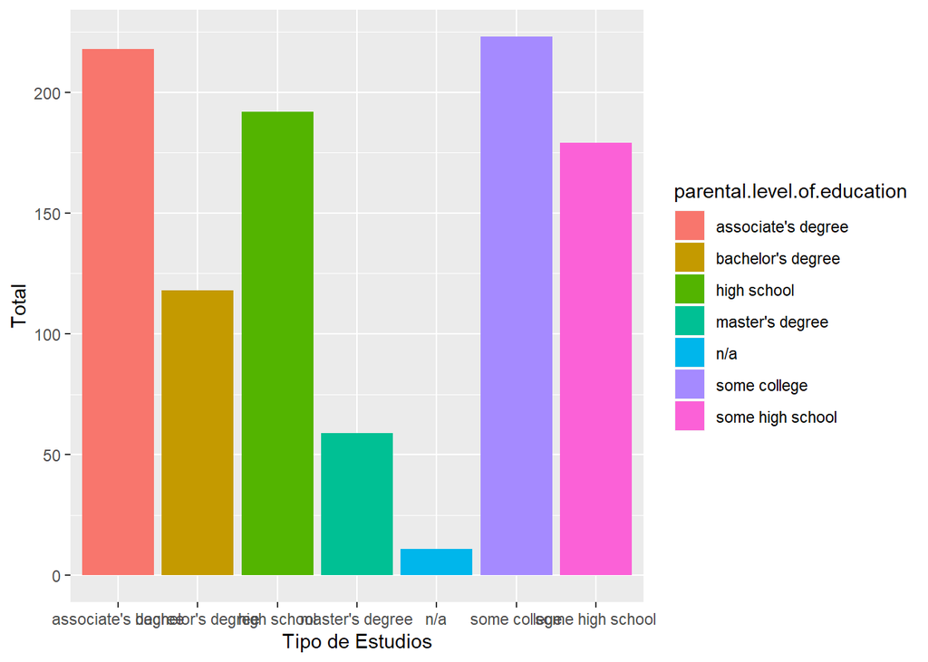

```r
parents_degree <- ggplot(data = ds,
                         aes(x = parental.level.of.education, fill =
                               parental.level.of.education)) +
                  geom_bar(stat = "count") +
                  xlab("Tipo de Estudios") +
                  ylab("Total")

parents_degree
```

#### **COMEDOR**

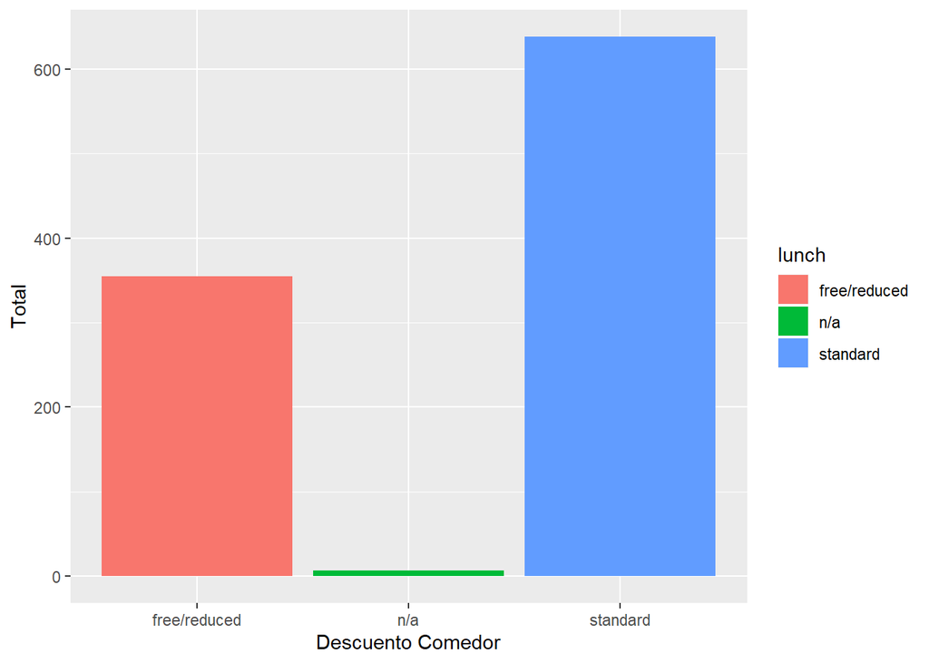

```r
lunch_plot <- ggplot(data = ds,
                aes(x = lunch, fill = lunch)) +
          geom_bar(stat = "count") +
          xlab("Descuento Comedor") +
          ylab("Total")
lunch_plot
```

#### **EXAMEN PREPARATORIO**

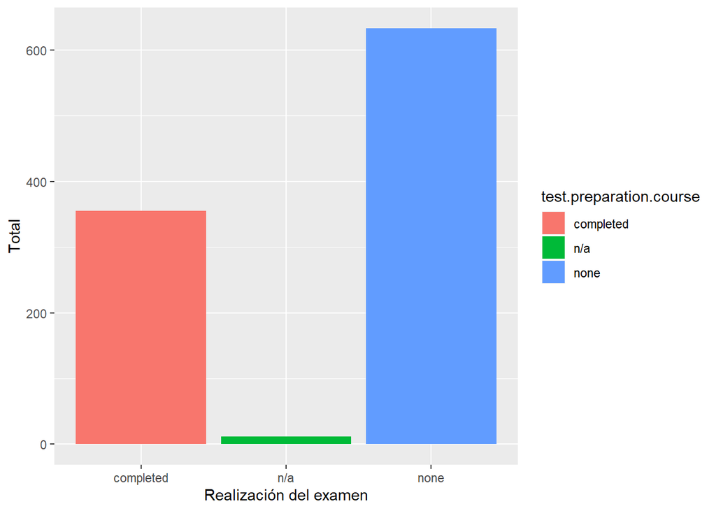

```r
prepration_plot <- ggplot(data = ds,
                     aes(x = test.preparation.course, fill = test.preparation.course)) +
              geom_bar(stat = "count") +
              xlab("Realización del examen") +
              ylab("Total")

prepration_plot
```

Con estos gráficos podemos analizar cómo están repartidos los datos en las variables y comprobar cuántos campos vacíos (n/a) tenemos en el dataset.

Por último, haremos una última representación gráfica donde se relacionan las notas en el *reading* y *writing*:

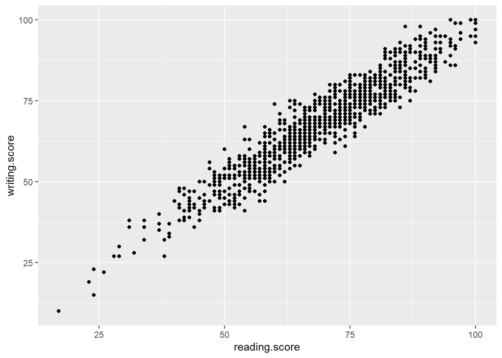

```r
scores_plot <- ggplot(ds, aes( reading.score, writing.score)) +
  geom_point()
scores_plot
```